# Predicting Classe: A Practical Machine Learning Project

Elmer C. Peramo

12/6/2018

## Background

Using devices such as *Jawbone Up, Nike FuelBand*, and Fitbit it is now possible to collect a large amount of data about personal activity relatively inexpensively. These type of devices are part of the quantified self movement – a group of enthusiasts who take measurements about themselves regularly to improve their health, to find patterns in their behavior, or because they are tech geeks. One thing that people regularly do is quantify how *much* of a particular activity they do, but they rarely quantify *how well they do it*. In this project, your goal will be to use data from accelerometers on the belt, forearm, arm, and dumbell of 6 participants. They were asked to perform barbell lifts correctly and incorrectly in 5 different ways. More information is available from the website here: http://groupware.les.inf.puc-rio.br/har (see the section on the Weight Lifting Exercise Dataset).

## Initial Preparation and Data Analysis

Loading the necessary packages for this project:

```r
library(dplyr)
library(lubridate)
library(caret)
```

```r
library(rpart)
library(rpart.plot)
library(rattle)
library(randomForest)
library(ggplot2)
```

## Data Loading

The training data for this project are available here:

https://d396qusza40orc.cloudfront.net/predmachlearn/pml-training.csv

The test data are available here:

https://d396qusza40orc.cloudfront.net/predmachlearn/pml-testing.csv

The data for this project come from this source: http://groupware.les.inf.puc-rio.br/har. If you use the document you create for this class for any purpose please cite them as they have been very generous in allowing their data to be used for this kind of assignment.

Assuming that I have already downloaded the pml-training.csv and pml-testing.csv and have set the working directory to where I’ve saved these files:

```r
dtrain<- read.csv("pml-training.csv", na.strings = c("NA", "#DIV/0!", ""))
dtest<- read.csv("pml-testing.csv", na.strings = c("NA", "#DIV/0!", ""))
```

## Exploratory Data Analyses

### Dimensions

```r
dim(dtrain)
```

```
## [1] 19622   160
```

### Structure

```r
str(dtrain)
```

```
## 'data.frame':    19622 obs. of  160 variables:
##  $ X                       : int  1 2 3 4 5 6 7 8 9 10 ...
##  $ user_name               : Factor w/ 6 levels "adelmo","carlitos",..: 2 2 2 2 2 2 2 2 2 2 ...
##  $ raw_timestamp_part_1    : int  1323084231 1323084231 1323084231 1323084232 1323084232 1323084232 1323084232 1323084232 1323084232 1323084232 ...
##  $ raw_timestamp_part_2    : int  788290 808298 820366 120339 196328 304277 368296 440390 484323 484434 ...
##  $ cvtd_timestamp          : Factor w/ 20 levels "02/12/2011 13:32",..: 9 9 9 9 9 9 9 9 9 9 ...
##  $ new_window              : Factor w/ 2 levels "no","yes": 1 1 1 1 1 1 1 1 1 1 ...
##  $ num_window              : int  11 11 11 12 12 12 12 12 12 12 ...
##  $ roll_belt               : num  1.41 1.41 1.42 1.48 1.48 1.45 1.42 1.42 1.43 1.45 ...
##  $ pitch_belt              : num  8.07 8.07 8.07 8.05 8.07 8.06 8.09 8.13 8.16 8.17 ...
##  $ yaw_belt                : num  -94.4 -94.4 -94.4 -94.4 -94.4 -94.4 -94.4 -94.4 -94.4 -94.4 ...
##  $ total_accel_belt        : int  3 3 3 3 3 3 3 3 3 3 ...
##  $ kurtosis_roll_belt      : num  NA NA NA NA NA NA NA NA NA NA ...
##  $ kurtosis_picth_belt     : num  NA NA NA NA NA NA NA NA NA NA ...
##  $ kurtosis_yaw_belt       : logi  NA NA NA NA NA NA ...
```

[output cut: 86 more lines]

### Samples

```r
head(dtrain)
```

[output not shown]

[output cut: 265 more lines]

### Descriptive Stats

```r
summary(dtrain)
```

```
##        X            user_name    raw_timestamp_part_1 raw_timestamp_part_2
##  Min.   :    1   adelmo  :3892   Min.   :1.322e+09    Min.   :   294
##  1st Qu.: 4906   carlitos:3112   1st Qu.:1.323e+09    1st Qu.:252912
##  Median : 9812   charles :3536   Median :1.323e+09    Median :496380
##  Mean   : 9812   eurico  :3070   Mean   :1.323e+09    Mean   :500656
##  3rd Qu.:14717   jeremy  :3402   3rd Qu.:1.323e+09    3rd Qu.:751891
##  Max.   :19622   pedro   :2610   Max.   :1.323e+09    Max.   :998801
##
##           cvtd_timestamp  new_window    num_window      roll_belt
##  28/11/2011 14:14: 1498   no :19216   Min.   :  1.0   Min.   :-28.90
##  05/12/2011 11:24: 1497   yes:  406   1st Qu.:222.0   1st Qu.:  1.10
##  30/11/2011 17:11: 1440               Median :424.0   Median :113.00
##  05/12/2011 11:25: 1425               Mean   :430.6   Mean   : 64.41
##  02/12/2011 14:57: 1380               3rd Qu.:644.0   3rd Qu.:123.00
##  02/12/2011 13:34: 1375               Max.   :864.0   Max.   :162.00
##  (Other)         :11007
##    pitch_belt          yaw_belt       total_accel_belt kurtosis_roll_belt
##  Min.   :-55.8000   Min.   :-180.00   Min.   : 0.00    Min.   :-2.121
##  1st Qu.:  1.7600   1st Qu.: -88.30   1st Qu.: 3.00    1st Qu.:-1.329
##  Median :  5.2800   Median : -13.00   Median :17.00    Median :-0.899
##  Mean   :  0.3053   Mean   : -11.21   Mean   :11.31    Mean   :-0.220
##  3rd Qu.: 14.9000   3rd Qu.:  12.90   3rd Qu.:18.00    3rd Qu.:-0.219
##  Max.   : 60.3000   Max.   : 179.00   Max.   :29.00    Max.   :33.000
##                                                        NA's   :19226
##  kurtosis_picth_belt kurtosis_yaw_belt skewness_roll_belt
##  Min.   :-2.190      Mode:logical      Min.   :-5.745
##  1st Qu.:-1.107      NA's:19622        1st Qu.:-0.444
##  Median :-0.151                        Median : 0.000
##  Mean   : 4.334                        Mean   :-0.026
##  3rd Qu.: 3.178                        3rd Qu.: 0.417
##  Max.   :58.000                        Max.   : 3.595
##  NA's   :19248                         NA's   :19225
##  skewness_roll_belt.1 skewness_yaw_belt max_roll_belt     max_picth_belt
##  Min.   :-7.616       Mode:logical      Min.   :-94.300   Min.   : 3.00
##  1st Qu.:-1.114       NA's:19622        1st Qu.:-88.000   1st Qu.: 5.00
##  Median :-0.068                         Median : -5.100   Median :18.00
##  Mean   :-0.296                         Mean   : -6.667   Mean   :12.92
##  3rd Qu.: 0.661                         3rd Qu.: 18.500   3rd Qu.:19.00
##  Max.   : 7.348                         Max.   :180.000   Max.   :30.00
##  NA's   :19248                          NA's   :19216     NA's   :19216
```

[output cut: 313 more lines]

```
##  Min.   :-446.00   Min.   :-1280.0   Min.   :-896.0   Min.   :-973.0
##  1st Qu.:-182.00   1st Qu.: -616.0   1st Qu.:   2.0   1st Qu.: 191.0
##  Median : -39.00   Median : -378.0   Median : 591.0   Median : 511.0
##  Mean   : -55.29   Mean   : -312.6   Mean   : 380.1   Mean   : 393.6
##  3rd Qu.:  26.00   3rd Qu.:  -73.0   3rd Qu.: 737.0   3rd Qu.: 653.0
##  Max.   : 291.00   Max.   :  672.0   Max.   :1480.0   Max.   :1090.0
##
##  classe
##  A:5580
##  B:3797
##  C:3422
##  D:3216
##  E:3607
##
##
```

### Transformation

```r
dtrain$cvtd_timestamp<- as.Date(dtrain$cvtd_timestamp, format = "%m/%d/%Y %H:%M")
dtrain$Day<-factor(weekdays(dtrain$cvtd_timestamp))
```

### Looking for insights

```r
table(dtrain$classe)
```

```
##
##    A    B    C    D    E
## 5580 3797 3422 3216 3607
```

```r
prop.table(table(dtrain$classe))
```

```
##
##         A         B         C         D         E
## 0.2843747 0.1935073 0.1743961 0.1638977 0.1838243
```

```r
table(dtrain$user_name)
```

```
##
##   adelmo carlitos  charles   eurico   jeremy    pedro
##     3892     3112     3536     3070     3402     2610
```

```r
prop.table(table(dtrain$user_name))
```

```
##
##    adelmo  carlitos   charles    eurico    jeremy     pedro
## 0.1983488 0.1585975 0.1802059 0.1564570 0.1733768 0.1330140
```

### Cleaning

```r
# Deleting unrelated fields
classe<- dtrain$classe
bad_col<- grepl("^X|timestamp|window", names(dtrain))
dtrain<- dtrain[, !bad_col]
dtrain<- dtrain[, sapply(dtrain, is.numeric)]
dtrain$classe<- classe
bad_col<- grepl("^X|timestamp|window", names(dtest))
dtest<- dtest[, !bad_col]
dtest<- dtest[, sapply(dtest, is.numeric)]
```

```r
# Deleting fields with missing values
dtrain <- dtrain[, colSums(is.na(dtrain)) == 0]
dtest <- dtest[, colSums(is.na(dtest)) == 0]
```

## Partition Data for Training and Testing

```r
set.seed(1125)
Trn <- createDataPartition(dtrain$classe, p=0.72, list=F)
train <- dtrain[Trn, ]
test <- dtrain[-Trn, ]
dim(train)
```

```
## [1] 14130    53
```

```r
dim(test)
```

```
## [1] 5492   53
```

## Using ML Algorithms

[figure not shown]

```r
train_c <- trainControl(method="cv", number=6)
c_tree <- train(classe~., data=train, method="rpart", trControl=train_c)
fancyRpartPlot(c_tree$finalModel)
```

```r
tr_pred <- predict(c_tree,newdata=test)
cm_ctree <- confusionMatrix(test$classe,tr_pred)

# confusion matrix and accuracy
cm_ctree$table
```

```
##           Reference
## Prediction    A    B    C    D    E
##          A 1418   27  115    0    2
##          B  436  371  256    0    0
##          C  431   31  496    0    0
##          D  388  164  348    0    0
##          E  137  132  266    0  474
```

```r
cm_ctree$overall[1]
```

```
##  Accuracy
## 0.5023671
```

### Random Forest

```r
c_rf <- train(classe~., data=train, method="rf", ntree=8, importance=TRUE, prox=TRUE, trControl=train_c)
c_rf
```

```
## Random Forest
##
## 14130 samples
##    52 predictor
##     5 classes: 'A', 'B', 'C', 'D', 'E'
##
## No pre-processing
## Resampling: Cross-Validated (6 fold)
## Summary of sample sizes: 11775, 11775, 11774, 11775, 11775, 11776, ...
## Resampling results across tuning parameters:
##
##   mtry  Accuracy   Kappa
##    2    0.9721864  0.9648095
##   27    0.9853501  0.9814679
##   52    0.9742385  0.9674128
##
## Accuracy was used to select the optimal model using the largest value.
## The final value used for the model was mtry = 27.
```

```r
fr_pred <- predict(c_rf,newdata=test)
cm_rf <-confusionMatrix(test$classe,fr_pred)
cm_rf$table
```

```
##           Reference
## Prediction    A    B    C    D    E
##          A 1558    2    2    0    0
##          B   11 1044    6    2    0
##          C    0    9  940    8    1
##          D    0    5   11  883    1
##          E    0    2    3    3 1001
```

```r
cm_rf$overall[1]
```

```
##  Accuracy
## 0.9879825
```

### Getting a Single Tree

```r
getTree(c_rf$finalModel, k=2)
```

[output not shown]

[output cut: 931 more lines]

### Class Centers

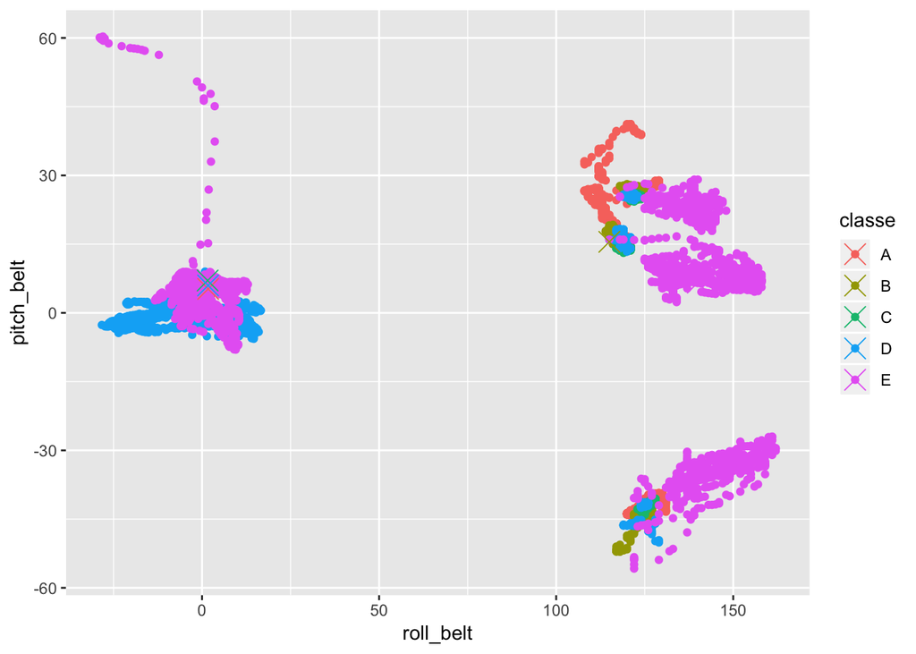

```r
data <- classCenter(train[,c(1,2)], train$classe, c_rf$finalModel$prox)
data <- as.data.frame(data);data$classe <- rownames(data)
p <- qplot(roll_belt,pitch_belt,color=classe, data = train)
p + geom_point(aes(x=roll_belt,y=pitch_belt,col=classe),size=5,shape=4,data = data)
```

## Conclusion

Comparing the two algorithms, it clearly shows that Random Forest is the better model. So, I will use it to predict the values of classe in the untouched test data set.

```r
validation <- predict(c_rf,newdata=dtest)
validation
```

```
##  [1] B A B A A E D B A A B C B A E E A B B B
## Levels: A B C D E
```